# BMS353 Week 6

November 2020

## Week 5 Recap

- Adding extra annotation to differential expression results
  - Bioconductor packages
  - biomaRt
- Visualisations to help interogate results
  - heatmaps
  - volcano plots

## Week 6 Overview

- Towards biological interpretation
- What pathways or biological processes explain the gene list
- Two types of test
  - Apply significance cut-off to the results
  - Rank the gene list
- Overview of assignment

## So you’ve got your gene list: what now?

- We have used an annotation resource to convert our IDs to something more meanginful
- Useful if we have a particular positive of negative control
  - e.g. a gene that has been knocked-out
  - genes know from the literature

```
##              ENSEMBL          padj   SYMBOL
## 1 ENSMUSG00000027750  0.000000e+00    Postn
## 2 ENSMUSG00000022371 8.560150e-254  Col14a1
## 3 ENSMUSG00000061048 5.244521e-195     Cdh3
## 4 ENSMUSG00000061527 5.386067e-187     Krt5
## 5 ENSMUSG00000040118 1.270296e-181 Cacna2d1
```

## So you’ve got your gene list: what now?

- The same resource can be used to obtain membership of *gene ontologies*
  - collection of genes that share biological function
- There are lots of pathways identified, so we need a statistical test to determine if any occur more often than we expect.

```
## # A tibble: 5 x 4
## # Groups:   ENSEMBL [5]
##   ENSEMBL             padj SYMBOL  GO
##   <chr>              <dbl> <chr>   <chr>
## 1 ENSMUSG000000~ 0.        Postn   GO:0001953,GO:0003073,GO:0005201,GO:0005576,~
## 2 ENSMUSG000000~ 8.56e-254 Col14a1 GO:0003229,GO:0003429,GO:0005576,GO:0005581,~
## 3 ENSMUSG000000~ 5.24e-195 Cdh3    GO:0000902,GO:0001895,GO:0005509,GO:0005737,~
## 4 ENSMUSG000000~ 5.39e-187 Krt5    GO:0005515,GO:0005737,GO:0005739,GO:0005882,~
## 5 ENSMUSG000000~ 1.27e-181 Cacna2~ GO:0005244,GO:0005245,GO:0005245,GO:0005262,~
```

## Testing for significance

- We can count up how many times each pathway is seen
- But this can be deceiving
  - not all pathways are of equal size (from a few genes to a few thousand)
- If the gene list were random, with no biological significance, we would still get a particular distribution of pathways

```
##               GO    n
## 1     GO:0016020 2746
## 2     GO:0005737 2726
## 3     GO:0005634 2257
## 4     GO:0005886 2155
## 5     GO:0016021 1900
## 6     GO:0005515 1800
## 7     GO:0005829 1170
## 8     GO:0003674 1063
## 9     GO:0005615 1035
## 10    GO:0046872 1032
## 11    GO:0005739  867
## 12    GO:0008150  852
## 13    GO:0005576  743
## 14    GO:0005783  704
```

[output cut: 12598 more lines]

## Testing for Significance

- Aim is to compare number of differentially-expressed genes for each pathway - to how many we expect by chance
- This can be done using a *Fisher’s exact test* or chi-squared test (R will take care of this for us)
  - \[ p = \frac{\binom{a + b}{a}\binom{c +d}{c}}{\binom{n}{a +c}} = \frac{(a+b)!(c+d)!(a+c)!(b+d)!}{a!b!c!d!n!} \]
- Result is p-value for *each pathway*

```
##                 In.DE.List Not.in.DE.list     RowTotal
## In Gene Set              a              b         a +b
## Not in Gene Set          c              d          c+d
## Column Total           a+c            b+d a+b+c+d (=n)
```

## Alternative approach

- All of the above assumes we impose a threshold on our data
- Are genes with p-value 0.051 any less significant? Or genes with log-fold change 0.99?
- What happens if we don’t get any, or very few, genes?
- An alternative approach exists that takes information from *all genes*

## The GSEA method

- The Gene Set Enrichment Analysis (GSEA) tool created by the Broad Institute can be used in such circumstances
- No threshold are required, but the results must be ranked by a criteria with directionality such as log fold-change
- Seeks to identify pathways with a tendency to be at top or bottom of ranked gene list

## The GSEA method

- For each gene set in turn, walk-down the gene list and record every time a gene belonging to that pathway is seen
- For a *down-regulated* gene set, the genes belonging to it would be concentrated towards the *bottom* of the gene list

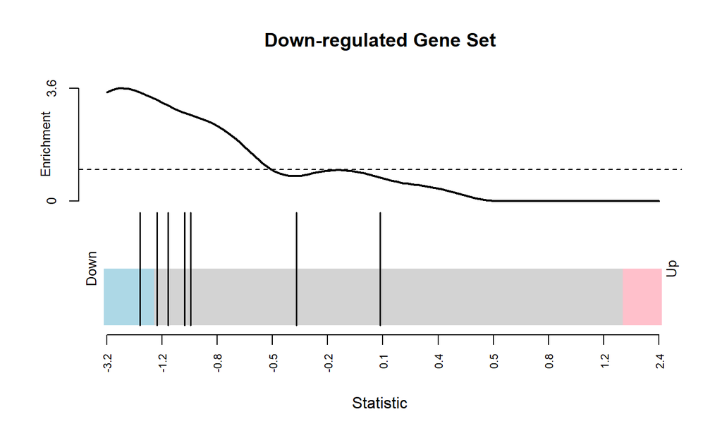

## The GSEA method

- For an *up-regulated* gene set, the genes belonging to it would be concentrated towards the *top* of the gene list

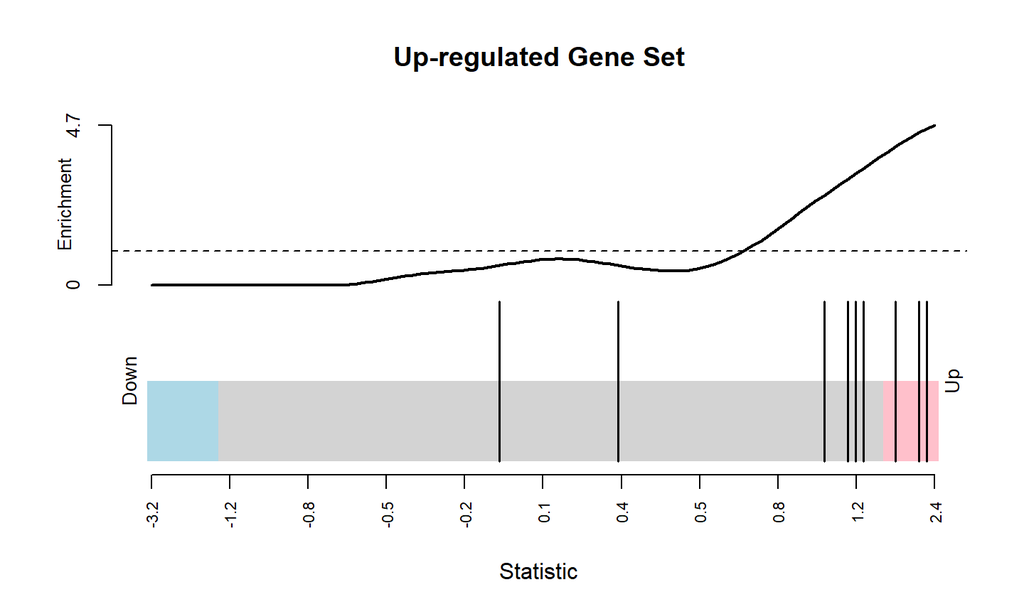

## The GSEA method

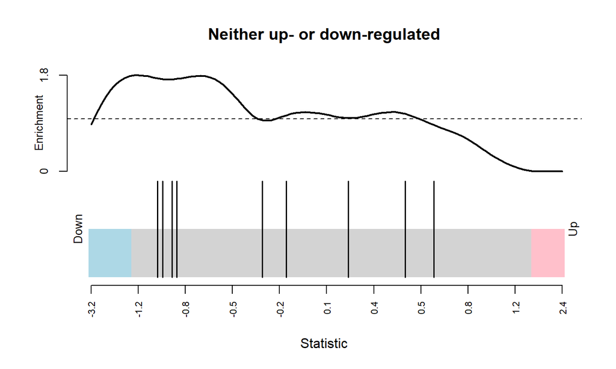